# h2o.ai demo

## Acknowledgements

These are customized from Erin LeDell’s materials.

## General dependencies

Other than h2o, we will use `caret`, `mlbench`, and `cvAUC` R packages.

## Install h2o

Follow the instructions at http://h2o.ai/download (click “Latest stable release” button then the “Install in R” tab.)

## Install h2oEnsemble

```r
devtools::install_github("h2oai/h2o-3/h2o-r/ensemble/h2oEnsemble-package")
```

## Start h2o cluster

```r
# This will load the h2o R package as well.
library(h2oEnsemble)
# Start an H2O cluster with nthreads = num cores on your machine.
# -1 means to use all cores.
h2o.init(nthreads = -1)
```

```
##  Connection successful!
##
## R is connected to the H2O cluster:
##     H2O cluster uptime:         34 minutes 49 seconds
##     H2O cluster version:        3.10.0.6
##     H2O cluster version age:    1 month and 28 days
##     H2O cluster name:           H2O_started_from_R_chrisken_gjo928
##     H2O cluster total nodes:    1
##     H2O cluster total memory:   3.41 GB
##     H2O cluster total cores:    8
##     H2O cluster allowed cores:  2
##     H2O cluster healthy:        TRUE
##     H2O Connection ip:          localhost
##     H2O Connection port:        54321
##     H2O Connection proxy:       NA
##     R Version:                  R version 3.3.1 (2016-06-21)
```

```r
# Clean slate - just in case the cluster was already running.
h2o.removeAll()
```

```
## [1] 0
```

## Setup dataset

We will use the BreastCancer dataset from the mlbench package, where the outcome variable is whether the cancer cell is malignant. We have a little cleaning to do to setup the dataset for modeling.

```r
############################
# Setup test dataset from mlbench.

# NOTE: install mlbench package if you don't already have it.
data(BreastCancer, package = "mlbench")

# Specify our outcome variable.
y = "Class"

# Remove missing values - could impute for improved accuracy.
data = na.omit(BreastCancer)

# Remove ID column and outcome variable.
# Save as a new df so that we can add outcome back later.
data2 = data[, !names(data) %in% c("Id", y)]

str(data2)
```

```
## 'data.frame':    683 obs. of  9 variables:
##  $ Cl.thickness   : Ord.factor w/ 10 levels "1"<"2"<"3"<"4"<..: 5 5 3 6 4 8 1 2 2 4 ...
##  $ Cell.size      : Ord.factor w/ 10 levels "1"<"2"<"3"<"4"<..: 1 4 1 8 1 10 1 1 1 2 ...
##  $ Cell.shape     : Ord.factor w/ 10 levels "1"<"2"<"3"<"4"<..: 1 4 1 8 1 10 1 2 1 1 ...
##  $ Marg.adhesion  : Ord.factor w/ 10 levels "1"<"2"<"3"<"4"<..: 1 5 1 1 3 8 1 1 1 1 ...
##  $ Epith.c.size   : Ord.factor w/ 10 levels "1"<"2"<"3"<"4"<..: 2 7 2 3 2 7 2 2 2 2 ...
##  $ Bare.nuclei    : Factor w/ 10 levels "1","2","3","4",..: 1 10 2 4 1 10 10 1 1 1 ...
##  $ Bl.cromatin    : Factor w/ 10 levels "1","2","3","4",..: 3 3 3 3 3 9 3 3 1 2 ...
##  $ Normal.nucleoli: Factor w/ 10 levels "1","2","3","4",..: 1 2 1 7 1 7 1 1 1 1 ...
##  $ Mitoses        : Factor w/ 9 levels "1","2","3","4",..: 1 1 1 1 1 1 1 1 5 1 ...
```

```r
# Expand out factors into indicators (ignore ordinality of several factors).
# Alternatively we could convert the ordinal factors to numerics.
data2 = data.frame(model.matrix( ~ . - 1, data = data2))

# Check dimensions after we expand our dataset.
dim(data2)
```

```
## [1] 683  81
```

```r
library(caret)
# Remove zero variance (constant) and near-zero-variance columns.
# This can help reduce overfitting and also helps us use a basic glm().
# However, there is a slight risk that we are discarding helpful information.
preproc = caret::preProcess(data2, method = c("zv", "nzv"))
data2 = predict(preproc, data2)
rm(preproc)

# Review our dimensions.
dim(data2)
```

```
## [1] 683  52
```

```r
# Add outcome back into dataframe as initial column.
data2 = cbind(data[, y], data2)

# Recover outcome name.
colnames(data2)[1] = y

# Review final dataset structure.
str(data2)
```

```
## 'data.frame':    683 obs. of  53 variables:
##  $ Class            : Factor w/ 2 levels "benign","malignant": 1 1 1 1 1 2 1 1 1 1 ...
##  $ Cl.thickness1    : num  0 0 0 0 0 0 1 0 0 0 ...
##  $ Cl.thickness2    : num  0 0 0 0 0 0 0 1 1 0 ...
##  $ Cl.thickness3    : num  0 0 1 0 0 0 0 0 0 0 ...
##  $ Cl.thickness4    : num  0 0 0 0 1 0 0 0 0 1 ...
##  $ Cl.thickness5    : num  1 1 0 0 0 0 0 0 0 0 ...
##  $ Cl.thickness8    : num  0 0 0 0 0 1 0 0 0 0 ...
##  $ Cl.thickness10   : num  0 0 0 0 0 0 0 0 0 0 ...
##  $ Cell.size.L      : num  -0.495 -0.165 -0.495 0.275 -0.495 ...
##  $ Cell.size.Q      : num  0.522 -0.261 0.522 -0.087 0.522 ...
##  $ Cell.size.C      : num  -0.453 0.335 -0.453 -0.378 -0.453 ...
##  $ Cell.size.4      : num  0.3366 0.0561 0.3366 -0.3179 0.3366 ...
##  $ Cell.size.5      : num  -0.2148 -0.3939 -0.2148 0.0358 -0.2148 ...
##  $ Cell.size.6      : num  0.117 0.234 0.117 0.389 0.117 ...
```

[output cut: 39 more lines]

```r
# Clean up
rm(data, BreastCancer)
```

## Loading data

```r
# Load data into h2o.
data = as.h2o(data2)
# Or use h2o.importFile() to import directly from CSVs.

# Check dimensions.
dim(data)
```

```
## [1] 683  53
```

```r
# Check distribution of outcome variable.
summary(data[, y], exact_quantiles = T)
```

```
##  Class
##  benign   :444
##  malignant:239
```

```r
# Divide into training (70%) and holdout (30%).
# We need to set an h2o-specific seed for reproducibility.
# If we used splits of less than 100%, h2o would allocate a third split to the
# remainder.
splits = h2o.splitFrame(data, 0.7, seed = 1234)

# Allocate the training split to a new dataframe in h2o.
train_frame = h2o.assign(splits[[1]], "train")

# Check dimensions
dim(train_frame)
```

```
## [1] 492  53
```

```r
# Allocate the holdout split to a new dataframe in h2o.
holdout_frame = h2o.assign(splits[[2]], "holdout")

# Check dimensions
dim(holdout_frame)
```

```
## [1] 191  53
```

```r
# Specify the names of our predictors, removing our target variable.
features = setdiff(names(data), y)
```

## Train ensemble

We will use the glm, randomForest, and GBM (gradient boosted machines) learners in the ensemble. Note that glm in h2o means elastic net, not OLS.

```r
learners = c("h2o.glm.wrapper", "h2o.randomForest.wrapper",
             "h2o.gbm.wrapper")

# Deeplearner would be h2o.deeplearning.wrapper

# We can create a non-negative least squared learner by specifying
# non_negative = T. We can also avoid the elastic net penalization
# (if we prefer) by setting lambda = 0.
# There appears to be a bug where intercept = F is not processed correctly.
h2o.glm_nn = function(...) {
  h2o.glm.wrapper(..., non_negative = T, lambda = 0, intercept = F)
}

metalearner = "h2o.glm_nn"

# Alternative simple metalearner:
#metalearner = "h2o.glm.wrapper"

fit_ens = h2o.ensemble(x = features, y = y,  training_frame = train_frame,
                    family = "AUTO",  learner = learners,
                    metalearner = metalearner, cvControl = list(V = 5))
```

```
##
## [1] "Cross-validating and training base learner 1: h2o.glm.wrapper"
##
## [1] "Cross-validating and training base learner 2: h2o.randomForest.wrapper"
##
## [1] "Cross-validating and training base learner 3: h2o.gbm.wrapper"
##
## [1] "Metalearning"
##
```

```r
# The metafit element contains the model weights and other details.
fit_ens$metafit
```

```
## Model Details:
## ==============
##
## H2OBinomialModel: glm
## Model ID:  GLM_model_R_1477332277351_42844
## GLM Model: summary
##     family  link regularization number_of_predictors_total
## 1 binomial logit           None                          3
##   number_of_active_predictors number_of_iterations   training_frame
## 1                           3                    6 RTMP_sid_8a95_15
##
## Coefficients: glm coefficients
##                      names coefficients standardized_coefficients
## 1                Intercept    -4.038382                 -1.345999
## 2          h2o.glm.wrapper     1.286199                  0.604702
## 3 h2o.randomForest.wrapper     3.974878                  1.694759
## 4          h2o.gbm.wrapper     2.644952                  1.173416
##
## H2OBinomialMetrics: glm
## ** Reported on training data. **
##
## MSE:  0.03882052
## RMSE:  0.1970292
## LogLoss:  0.1486662
## Mean Per-Class Error:  0.05066404
## AUC:  0.984369
## Gini:  0.968738
## R^2:  0.8288053
## Null Deviance:  635.5889
## Residual Deviance:  146.2875
## AIC:  154.2875
##
## Confusion Matrix for F1-optimal threshold:
##           benign malignant    Error     Rate
## benign       311        10 0.031153  =10/321
## malignant     12       159 0.070175  =12/171
## Totals       323       169 0.044715  =22/492
##
## Maximum Metrics: Maximum metrics at their respective thresholds
##                         metric threshold    value idx
## 1                       max f1  0.488191 0.935294 168
## 2                       max f2  0.036347 0.951577 203
## 3                 max f0point5  0.617639 0.944645 164
## 4                 max accuracy  0.617639 0.955285 164
## 5                max precision  0.979319 1.000000   0
## 6                   max recall  0.017606 1.000000 331
## 7              max specificity  0.979319 1.000000   0
## 8             max absolute_mcc  0.488191 0.901171 168
## 9   max min_per_class_accuracy  0.272927 0.943925 179
## 10 max mean_per_class_accuracy  0.206313 0.952861 183
##
## Gains/Lift Table: Extract with `h2o.gainsLift(<model>, <data>)` or `h2o.gainsLift(<model>, valid=<T/F>, xval=<T/F>)`
```

## Predict

```r
pred = predict(fit_ens, holdout_frame)
# Third column is P(Y == 1)
predictions = as.data.frame(pred$pred)[, 3]
labels = as.data.frame(holdout_frame[, y])[, 1]
```

## Review performance

We can use the holdout data to estimate our general performance, both for the ensemble and each individual learner.

```r
library(cvAUC)
# Review performance of final ensemble.
cvAUC::AUC(predictions = predictions, labels = labels)
```

```
## [1] 0.9928264
```

```r
# Look at performance of individual learners (algorithms).
num_learners = length(learners)
aucs = sapply(1:num_learners, function(l) {
  cvAUC::AUC(predictions = as.data.frame(pred$basepred)[, l], labels = labels)
})
data.frame(learners, aucs)
```

```
##                   learners      aucs
## 1          h2o.glm.wrapper 0.9732186
## 2 h2o.randomForest.wrapper 0.9934242
## 3          h2o.gbm.wrapper 0.9948589
```

If we had used the deep learning wrapper the ensemble results would not be reproducible.

## Review models

Let’s review the underlying randomForest model to get a better sense of what happened. The `basefits` element of our ensemble contains the information on the individual learners.

For randomForest we have two performance estimates: 1) those from the cross-validation and 2) the out-of-bag estimates.

```r
names(fit_ens)
```

```
##  [1] "x"                   "y"                   "family"
##  [4] "learner"             "metalearner"         "cvControl"
##  [7] "folds"               "ylim"                "seed"
## [10] "parallel"            "basefits"            "metafit"
## [13] "levelone"            "runtime"             "h2o_version"
## [16] "h2oEnsemble_version"
```

```r
# Review modeling metrics, both OOB and via cross-validation.
fit_ens$basefits$h2o.randomForest.wrapper
```

```
## Model Details:
## ==============
##
## H2OBinomialModel: drf
## Model ID:  DRF_model_R_1477332277351_40592
## Model Summary:
##   number_of_trees number_of_internal_trees model_size_in_bytes min_depth
## 1              50                       50               21344         7
##   max_depth mean_depth min_leaves max_leaves mean_leaves
## 1        14    9.40000         20         38    28.88000
##
##
## H2OBinomialMetrics: drf
## ** Reported on training data. **
## ** Metrics reported on Out-Of-Bag training samples **
##
## MSE:  0.04424546
## RMSE:  0.210346
## LogLoss:  0.3333137
## Mean Per-Class Error:  0.05298683
## AUC:  0.9808074
## Gini:  0.9616148
##
## Confusion Matrix for F1-optimal threshold:
##           benign malignant    Error     Rate
## benign       302        19 0.059190  =19/321
## malignant      8       163 0.046784   =8/171
## Totals       310       182 0.054878  =27/492
##
## Maximum Metrics: Maximum metrics at their respective thresholds
##                         metric threshold    value idx
## 1                       max f1  0.400000 0.923513  63
## 2                       max f2  0.181818 0.950226  79
## 3                 max f0point5  0.714286 0.932416  43
## 4                 max accuracy  0.523810 0.945122  58
## 5                max precision  0.952381 0.977273   4
## 6                   max recall  0.000000 1.000000 104
## 7              max specificity  1.000000 0.993769   0
## 8             max absolute_mcc  0.400000 0.881829  63
## 9   max min_per_class_accuracy  0.461538 0.943925  61
```

[output cut: 61 more lines]

```
## f0point5                  0.9415584   0.8955224   0.9328358
## f1                        0.9508197   0.9230769   0.9433962
## f2                        0.9602649  0.95238096   0.9541985
## lift_top_group                  3.3   2.6756756   3.7307692
## logloss                  0.12891458  0.19807465  0.17821003
## max_per_class_error     0.033333335  0.08064516  0.03846154
## mcc                       0.9291911   0.8764259   0.9224408
## mean_per_class_accuracy   0.9688406   0.9461639   0.9666847
## mean_per_class_error     0.03115942 0.053836092 0.033315275
## mse                      0.03890106  0.05915821 0.035780508
## precision                 0.9354839   0.8780488   0.9259259
## r2                       0.81581193   0.7472495  0.81762797
## recall                   0.96666664    0.972973  0.96153843
## rmse                     0.19723351   0.2432246  0.18915735
## specificity               0.9710145  0.91935486  0.97183096
```

```r
# Review variable importance.
# Warning: this is not a true parameter as Mark has mentioned, so we
# have no inference on these results.
h2o.varimp(fit_ens$basefits$h2o.randomForest.wrapper)
```

```
## Variable Importances:
##         variable relative_importance scaled_importance percentage
## 1    Cell.size.L         1009.379639          1.000000   0.219072
## 2   Cell.shape.L          542.101501          0.537064   0.117656
## 3 Epith.c.size.L          408.405273          0.404610   0.088639
## 4    Cell.size.C          369.116211          0.365686   0.080112
## 5   Cell.shape.C          335.776306          0.332656   0.072876
##
## ---
##            variable relative_importance scaled_importance percentage
## 47         Mitoses2            6.079095          0.006023   0.001319
## 48    Cl.thickness3            5.552496          0.005501   0.001205
## 49    Cl.thickness8            5.395923          0.005346   0.001171
## 50 Normal.nucleoli3            4.766089          0.004722   0.001034
## 51    Cl.thickness2            3.000608          0.002973   0.000651
## 52    Cl.thickness1            2.056768          0.002038   0.000446
```

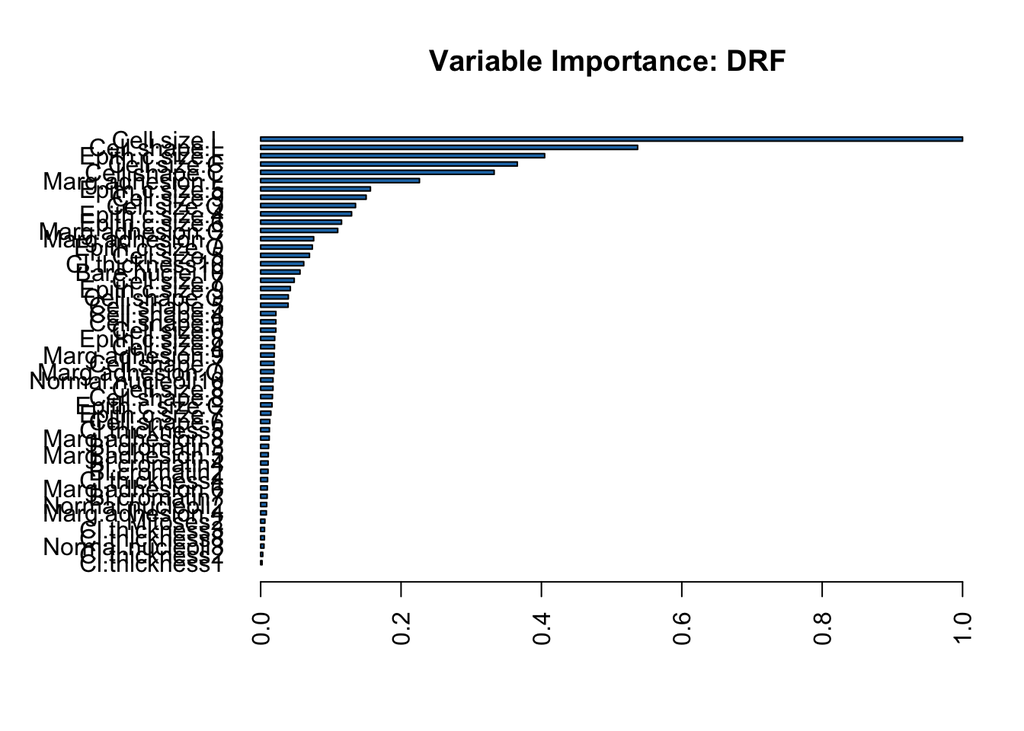

```r
# Plot variable importance.
h2o.varimp_plot(fit_ens$basefits$h2o.randomForest.wrapper)
```

We could also review the GBM and elastic net results.

## Customizing hyperparameters

Let’s increase the number of trees in the randomForest and the number of bins. h2o discretizes continuous variables via a histogram, which is much faster than checking all possible values for decision tree splitting. But it’s not exactly what Leo Breiman’s Random Forest does.

```r
# Increase number of trees and number of histogram bins for continuous variables.
h2o.randomForest.1 = function(...) {
  h2o.randomForest.wrapper(..., ntrees = 200, nbins = 50, seed = 1)
}

new_library = learner <- c("h2o.glm.wrapper", "h2o.randomForest.wrapper",
             "h2o.randomForest.1", "h2o.gbm.wrapper")

fit = h2o.ensemble(x = features, y = y,
                    training_frame = train_frame,
                    family = "AUTO",
                    learner = new_library,
                    metalearner = metalearner,
                    cvControl = list(V = 5))
```

```
##
## [1] "Cross-validating and training base learner 1: h2o.glm.wrapper"
##
## [1] "Cross-validating and training base learner 2: h2o.randomForest.wrapper"
##
## [1] "Cross-validating and training base learner 3: h2o.randomForest.1"
##
## [1] "Cross-validating and training base learner 4: h2o.gbm.wrapper"
##
## [1] "Metalearning"
##
```

```r
fit$metafit
```

```
## Model Details:
## ==============
##
## H2OBinomialModel: glm
## Model ID:  GLM_model_R_1477332277351_47966
## GLM Model: summary
##     family  link regularization number_of_predictors_total
## 1 binomial logit           None                          4
##   number_of_active_predictors number_of_iterations   training_frame
## 1                           4                    6 RTMP_sid_8a95_32
##
## Coefficients: glm coefficients
##                      names coefficients standardized_coefficients
## 1                Intercept    -4.157166                 -1.378921
## 2          h2o.glm.wrapper     1.045097                  0.491349
## 3 h2o.randomForest.wrapper     3.925049                  1.662402
## 4       h2o.randomForest.1     1.884872                  0.794980
## 5          h2o.gbm.wrapper     1.364767                  0.605470
##
## H2OBinomialMetrics: glm
## ** Reported on training data. **
##
## MSE:  0.03857413
## RMSE:  0.196403
## LogLoss:  0.144344
## Mean Per-Class Error:  0.04910641
## AUC:  0.9875936
## Gini:  0.9751872
## R^2:  0.8298918
## Null Deviance:  635.5889
## Residual Deviance:  142.0345
## AIC:  152.0345
##
## Confusion Matrix for F1-optimal threshold:
##           benign malignant    Error     Rate
## benign       312         9 0.028037   =9/321
## malignant     12       159 0.070175  =12/171
## Totals       324       168 0.042683  =21/492
##
## Maximum Metrics: Maximum metrics at their respective thresholds
##                         metric threshold    value idx
## 1                       max f1  0.520036 0.938053 167
## 2                       max f2  0.106175 0.955631 194
## 3                 max f0point5  0.520036 0.943060 167
## 4                 max accuracy  0.520036 0.957317 167
## 5                max precision  0.982986 1.000000   0
## 6                   max recall  0.015836 1.000000 263
## 7              max specificity  0.982986 1.000000   0
## 8             max absolute_mcc  0.520036 0.905581 167
## 9   max min_per_class_accuracy  0.387025 0.947368 174
## 10 max mean_per_class_accuracy  0.387025 0.953435 174
##
## Gains/Lift Table: Extract with `h2o.gainsLift(<model>, <data>)` or `h2o.gainsLift(<model>, valid=<T/F>, xval=<T/F>)`
```

And review the performance again.

```r
pred = predict(fit, holdout_frame)
# Third column is P(Y == 1)
predictions = as.data.frame(pred$pred)[, 3]
labels = as.data.frame(holdout_frame[, y])[, 1]

# Review performance of final ensemble.
cvAUC::AUC(predictions = predictions, labels = labels)
```

```
## [1] 0.9933046
```

```r
# Look at performance of individual learners (algorithms).
num_learners = length(new_library)
aucs = sapply(1:num_learners, function(l) {
  cvAUC::AUC(predictions = as.data.frame(pred$basepred)[, l], labels = labels)
})
data.frame(new_library, aucs)
```

```
##                new_library      aucs
## 1          h2o.glm.wrapper 0.9732186
## 2 h2o.randomForest.wrapper 0.9939622
## 3       h2o.randomForest.1 0.9915112
## 4          h2o.gbm.wrapper 0.9948589
```

## Random Grid Search

Demo of random grid search, all from Erin LeDell’s code. This will be pretty slow. First we fit the base models.

```r
# Random Grid Search (e.g. 120 second maximum)
# This is set to run fairly quickly, increase max_runtime_secs
# or max_models to cover more of the hyperparameter space.
# Also, you can expand the hyperparameter space of each of the
# algorithms by modifying the hyper param code below.

search_criteria <- list(strategy = "RandomDiscrete",
                        max_runtime_secs = 120)
nfolds <- 5

# GBM Hyperparamters
learn_rate_opt <- c(0.01, 0.03)
max_depth_opt <- c(3, 4, 5, 6, 9)
sample_rate_opt <- c(0.7, 0.8, 0.9, 1.0)
col_sample_rate_opt <- c(0.2, 0.3, 0.4, 0.5, 0.6, 0.7, 0.8)
hyper_params <- list(learn_rate = learn_rate_opt,
                     max_depth = max_depth_opt,
                     sample_rate = sample_rate_opt,
                     col_sample_rate = col_sample_rate_opt)

gbm_grid <- h2o.grid("gbm", x = features, y = y,
                     training_frame = train_frame,
                     ntrees = 100,
                     seed = 1,
                     nfolds = nfolds,
                     fold_assignment = "Modulo",
                     keep_cross_validation_predictions = TRUE,
                     hyper_params = hyper_params,
                     search_criteria = search_criteria)
gbm_models <- lapply(gbm_grid@model_ids, function(model_id) h2o.getModel(model_id))



# RF Hyperparamters
mtries_opt <- 8:20
max_depth_opt <- c(5, 10, 15, 20, 25)
sample_rate_opt <- c(0.7, 0.8, 0.9, 1.0)
col_sample_rate_per_tree_opt <- c(0.2, 0.3, 0.4, 0.5, 0.6, 0.7, 0.8)
hyper_params <- list(mtries = mtries_opt,
                     max_depth = max_depth_opt,
                     sample_rate = sample_rate_opt,
                     col_sample_rate_per_tree = col_sample_rate_per_tree_opt)

rf_grid <- h2o.grid("randomForest", x = features, y = y,
                    training_frame = train_frame,
                    ntrees = 200,
                    seed = 1,
                    nfolds = nfolds,
                    fold_assignment = "Modulo",
                    keep_cross_validation_predictions = TRUE,
                    hyper_params = hyper_params,
                    search_criteria = search_criteria)
rf_models <- lapply(rf_grid@model_ids, function(model_id) h2o.getModel(model_id))

# GLM Hyperparamters
alpha_opt <- seq(0,1,0.1)
lambda_opt <- c(0,1e-7,1e-5,1e-3,1e-1)
hyper_params <- list(alpha = alpha_opt,
                     lambda = lambda_opt)

glm_grid <- h2o.grid("glm", x = features, y = y,
                     training_frame = train_frame,
                     family = "binomial",
                     nfolds = nfolds,
                     fold_assignment = "Modulo",
                     keep_cross_validation_predictions = TRUE,
                     hyper_params = hyper_params,
                     search_criteria = search_criteria)
glm_models <- lapply(glm_grid@model_ids, function(model_id) h2o.getModel(model_id))

# Create a list of all the base models
models <- c(gbm_models, rf_models, glm_models)
```

Combine the base models using different metalearners.

```r
# Specify a defalt GLM as the metalearner
metalearner <- "h2o.glm.wrapper"

# Let's stack!
stack <- h2o.stack(models = models,
                   response_frame = train_frame[, y],
                   metalearner = metalearner)
```

```
## [1] "Metalearning"
##
```

```r
# Compute test set performance:
perf <- h2o.ensemble_performance(stack, newdata = holdout_frame)
print(perf)
```

```
##
## Base learner performance, sorted by specified metric:
##                                                learner       AUC
## 42 Grid_GLM_train_model_R_1477332277351_80877_model_31 0.9323290
## 43  Grid_GLM_train_model_R_1477332277351_80877_model_9 0.9323290
## 44  Grid_GLM_train_model_R_1477332277351_80877_model_0 0.9323290
## 45 Grid_GLM_train_model_R_1477332277351_80877_model_12 0.9323290
## 46 Grid_GLM_train_model_R_1477332277351_80877_model_24 0.9323290
## 47 Grid_GLM_train_model_R_1477332277351_80877_model_29 0.9323290
## 48 Grid_GLM_train_model_R_1477332277351_80877_model_30 0.9323290
## 49 Grid_GLM_train_model_R_1477332277351_80877_model_19 0.9323290
## 50  Grid_GLM_train_model_R_1477332277351_80877_model_8 0.9323290
## 51 Grid_GLM_train_model_R_1477332277351_80877_model_10 0.9323290
## 40 Grid_GLM_train_model_R_1477332277351_80877_model_25 0.9623386
## 38  Grid_GLM_train_model_R_1477332277351_80877_model_6 0.9637733
```

[output cut: 46 more lines]

```r
# Compare to nnls.
stack2 <- h2o.metalearn(stack, metalearner = "h2o.glm_nn")
```

```
## [1] "Metalearning"
##
```

```r
perf2 <- h2o.ensemble_performance(stack2, newdata = holdout_frame, score_base_models = F)
print(perf2)
```

```
##
##
## H2O Ensemble Performance on <newdata>:
## ----------------
## Family: binomial
##
## Ensemble performance (AUC): 0.995217599234816
```

## Shut down cluster

```r
h2o.shutdown(prompt = F)
```